# Disease-Disease Associations and Visualization

Mustafa S Ascha

July 5, 2017

## 0.1 Motivation and Goals

- Copious amounts of transactions data are produced not just in industry, but in healthcare claims
- The curse of dimensionality makes explaining some of the relationships between item co-occurrence difficult
- Solution: use visualization as a decision support tool–by displaying large amounts of data in concise ways, new patterns may be revealed

## 0.2 What we have

- [Medicare data representing inpatient claims at the national level.](https://www.hcup-us.ahrq.gov/nisoverview.jsp)
- About 350,000 records of inpatient visits paid by Medicare
- 5 to 10 diagnoses per inpatient record
- Demographic data such as age, race, income quartile of patient zip code
- You can learn more about Medicare data [here](http://www.resdac.org/cms-data)

## 0.3 What we want

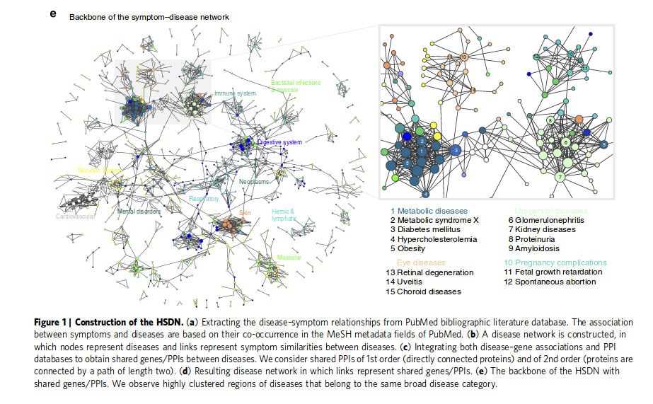

Zhou X, Menche J, Barabasi AL, Sharma A. Human symptoms-disease network. Nature communications; 26 June 2014. DOI: 10.1038/ncomms5212. http://barabasi.com/f/479.pdf

## 0.4 Problem: “Curse” of Dimensionality

We will use the Clinical Classification Software provided by the Agency for Healthcare Research and Quality to translate codes

- Produces meaningful descriptions
- Reduces dimensionality

```
## Observations: 288
## Variables: 2
## $ Diagnosis Code <chr> "47", "48", "49", "50", "51", "52", "53", "54",...
## $ Label          <chr> "Other and unspecified benign neoplasm", "Thyro...
```

## 0.5 Disease-disease relationships

- Size of node represents frequency of the diagnosis among all diagnoses
- Thickness of the edge connecting two nodes represents ‘lift’, which is how much more often we see the pair than we would expect if they occurred independently
- Selected relationships based on co-incidence metrics
- The following is a small (fewer nodes/edges) version of the associations, you can find the medium version [here](http://mustafa.fyi/assets/graph-medium) and the large version [here](http://mustafa.fyi/assets/graph-large.html)

[interactive chart not shown]

## 0.6 Obstetrics and related diagnoses

Looking at the above disease-disease relationship network, obstetrics-related trauma represents a prominent proportion of Medicare inpatient claims. One such condition is diabetes (we might expect it to be gestational diabetes), which is itself associated with presence of a previous C-section.

Even without medical knowledge, we might expect that the population of patients with a previous c-section would have a greater age than its counterpart because it usually takes about nine months to have a baby. Here is a plot showing evidence for this hypothesis:

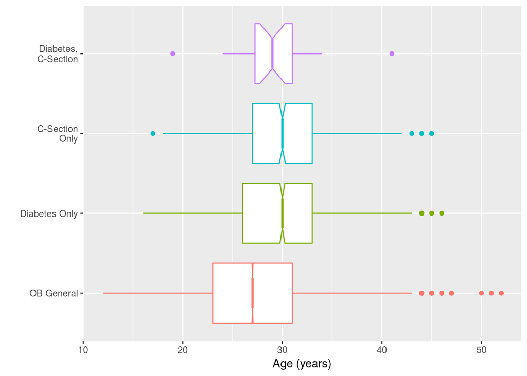

## 0.7 End

Thanks!